# Study notes

Ayesha A

2023-10-16

# 1 Inputting Data into R

How to enter data directly:

```r
c() # function combines objects of the same type (e.g., numbers/strings) into vectors
```

E.G., creating pupil number variable ‘pno’. Therefore, it would look like:

```r
pno <- seq(1:15)
```

for other variables, we need to manually input the data and separate with commas:

```r
sex <- c(1,1,2,1,2,2,1,2,2,1,1,2,1,1,2)
iq <- c(91,110,107,96,112,109,101,92,115,103,93,106,98,104,99)
happy <- c(5,5,2,4,1,1,4,2,1,3,5,2,5,2,3)
teachers <- c(4,3,2,4,1,5,2,1,3,4,5,1,4,2,2)
friends <- c(3,5,1,4,2,3,3,5,4,4,2,2,3,1,1)
```

the data will appear in the Environment tab, but it is not a dataframe yet.

# 2 Creating and checking Dataframes

```r
pupils <- data.frame(pno,sex,iq,happy,teachers,friends)
      # by entering pupils, you are able to see what is in the datafile
pupils
```

```
##    pno sex  iq happy teachers friends
## 1    1   1  91     5        4       3
## 2    2   1 110     5        3       5
## 3    3   2 107     2        2       1
## 4    4   1  96     4        4       4
## 5    5   2 112     1        1       2
## 6    6   2 109     1        5       3
## 7    7   1 101     4        2       3
## 8    8   2  92     2        1       5
## 9    9   2 115     1        3       4
## 10  10   1 103     3        4       4
## 11  11   1  93     5        5       2
## 12  12   2 106     2        1       2
## 13  13   1  98     5        4       3
## 14  14   1 104     2        2       1
## 15  15   2  99     3        2       1
```

Able to check the variables that’re in the DF by using names() FN

```r
names(pupils)
```

```
## [1] "pno"      "sex"      "iq"       "happy"    "teachers" "friends"
```

Once the DF is created with all the variables, you can use df$variableName to refer to any specific variable. E.G.,

```r
pupils$sex
```

```
##  [1] 1 1 2 1 2 2 1 2 2 1 1 2 1 1 2
```

# 3 Coding Variables as Factors (nominal categories)

For some variables like iQ, the entries are numerical values that represent some measurement (e.g., IQ test scores). For other variables such as sex, the values “1” and “2” have less meaning - labels for nominal categories. In this Dataset, 1 = Male, 2 = Female. We can use the *<factor()>* FN to turn the values in our variable, into nominal categories, and we can add labels to them. Below, the command converts the two values (levels) 1 and 2 into labels “Male” and “Female”.

```r
factor(pupils$sex, levels=c(1,2), labels=c("Male","Female"))
```

```
##  [1] Male   Male   Female Male   Female Female Male   Female Female Male
## [11] Male   Female Male   Male   Female
## Levels: Male Female
```

The above code assigns, but this does not save the new values into the DF. To save the recoded values, we have to assign the results of the factor() FN to the variable in the DF:

```r
pupils$sex <- factor(pupils$sex, levels=c(1,2), labels=c("Male","Female"))
# to view this:
View(pupils)
# if you use the head() FN to call the first few rows of data, there are now labels instead of numbers for the variable sex
head(pupils)
```

```
##   pno    sex  iq happy teachers friends
## 1   1   Male  91     5        4       3
## 2   2   Male 110     5        3       5
## 3   3 Female 107     2        2       1
## 4   4   Male  96     4        4       4
## 5   5 Female 112     1        1       2
## 6   6 Female 109     1        5       3
```

We can also note that for three more variables, **happy, teachers** and **friends**, the 5-point responses are *ordinal categories*, therefore they are ordered by decreasing happiness / popularity. However as there are more than 1-2 category codes, 1-5 is needed. This is done by:

```r
pupils$happy_f <- factor(pupils$happy, levels = c(1,2,3,4,5),
                         labels = c("Very happy", "Quite happy","Satisfied","Quite unhappy","Very unhappy"))
pupils$teachers_f <- factor(pupils$teachers, levels = c(1,2,3,4,5),
                            labels = c("Very popular", "Quite popular","Average","Quite unpopular","Very unpopular"))
pupils$friends_f <- factor(pupils$friends, levels = c(1,2,3,4,5),
                           labels = c("Very popular", "Quite popular","Average","Quite unpopular","Very unpopular"))
# if you check the dataframe, all of these labels have been assigned:
head(pupils)
```

```
##   pno    sex  iq happy teachers friends       happy_f      teachers_f
## 1   1   Male  91     5        4       3  Very unhappy Quite unpopular
## 2   2   Male 110     5        3       5  Very unhappy         Average
## 3   3 Female 107     2        2       1   Quite happy   Quite popular
## 4   4   Male  96     4        4       4 Quite unhappy Quite unpopular
## 5   5 Female 112     1        1       2    Very happy    Very popular
## 6   6 Female 109     1        5       3    Very happy  Very unpopular
##         friends_f
## 1         Average
## 2  Very unpopular
## 3    Very popular
## 4 Quite unpopular
## 5   Quite popular
## 6         Average
```

# 4 Saving Data

Saving dataframes into tab-delimited text or CSV (comma-separated values), allows these files to be opened and read easily by a variety of apps and stats packages. In order to save this data as a tab-delimited file, use the write.table() function. It takes the general form of:

```
write.table(dataframe, "filename.txt", sep = "\t", row.names=FALSE)
```

A name for the dataframe is needed, as well as one for the file name where you want to save it. You also need to indicate which separator you want to use (for tab-delimited, we want to use sep=“). Setting row.names = FALSE prevents R from exporting the column of row numbers, this is not necessary to save and can be viewed in R.

```r
write.csv(pupils, "pupils.csv", row.names=FALSE)
```

This saves the df as a .csv file which can be imported back into r.

# 5 Creating Basic Graphs

EXAMPLE: Plotting the number of pupils with each level of happiness (from 1=“very happy” to 5=“very unhappy”), using Base R Functionality.

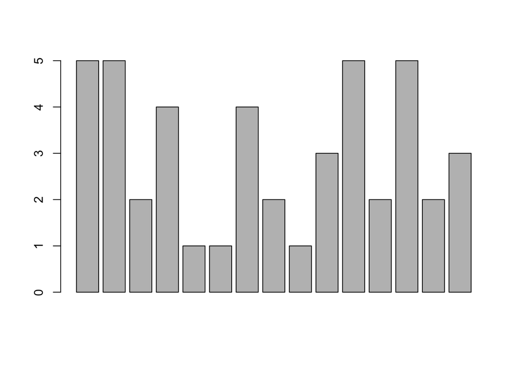

```r
barplot(pupils$happy)
```

This is not the desired outcome, as instead of counts of cases in each response category, we are getting the response value for every pupil. Therefore, we need to tabulate each of the happiness values, and only then to plot these counts as bars. For tabulating, we will use the table() FN.

```r
table(pupils$happy)
```

```
##
## 1 2 3 4 5
## 3 4 2 2 4
```

This table contains the category values from 1-5 in the first row, and the counts of response in each category in the 2nd row. A nicer format would be to have category labels instead, so we can use the happy_f variable to create the next table. This will use the barplot() FN:

```r
table(pupils$happy_f)
```

```
##
##    Very happy   Quite happy     Satisfied Quite unhappy  Very unhappy
##             3             4             2             2             4
```

then:

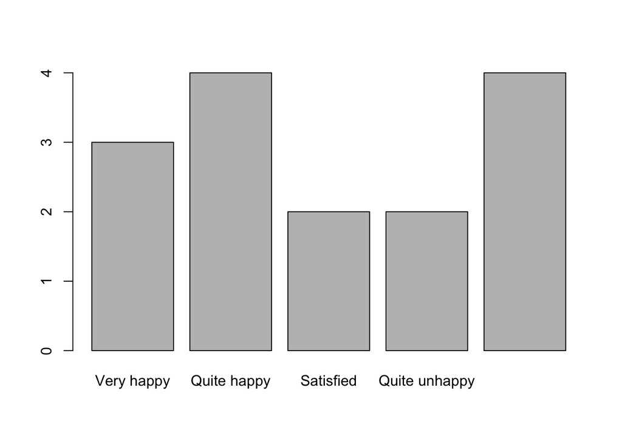

```r
barplot(table(pupils$happy_f))
```

To achieve the same thing, we can use ggplot2 package, and its FN ggplot(). The benefits of this are: - Colour options - Labels, etc In ggplot(), **aes** stands for aesthetics and this includes the variables to be plotted, colour, size, shape of objects, etc.

```r
library(ggplot2)
```

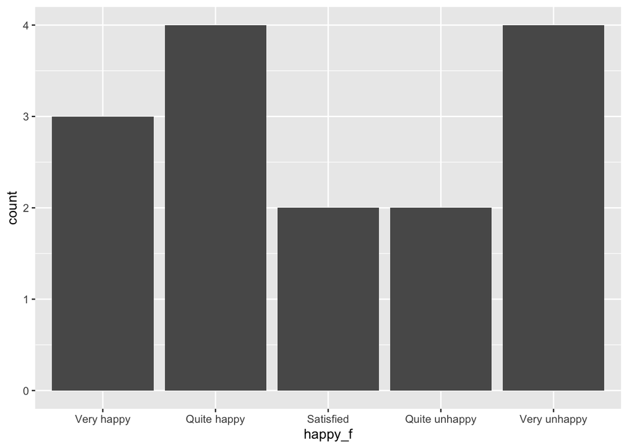

```r
# we start creating histograms by referring to variable happy from the df pupils
happyggBar <- ggplot(pupils, aes(happy_f))

# now we tell R to create a barplot from this given data
happyggBar + geom_bar()
```

We can then add axis labels

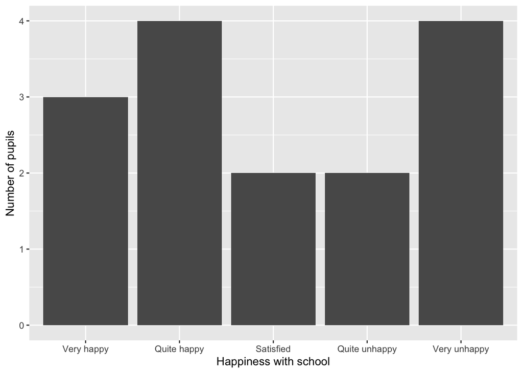

```r
happyggBar + geom_bar() + labs(x="Happiness with school", y="Number of pupils")
```

**Question 1.** Now try to produce a chart that shows the numbers of Males and Females in the dataset. Again, you can create counts for every value that the **sex** variable takes using the table() FN, and plot the counts using barplot() FN.

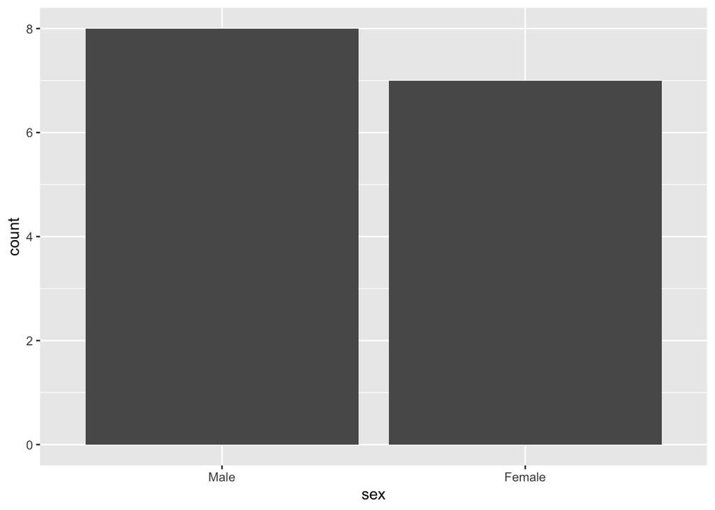

```r
ggplot(pupils, aes(sex)) + geom_bar()
```

# 6 Displaying frequencies within subsets of cases (The clustered bar chart)

Next, we may want to display happiness counts by **sex** (separately for males and females).

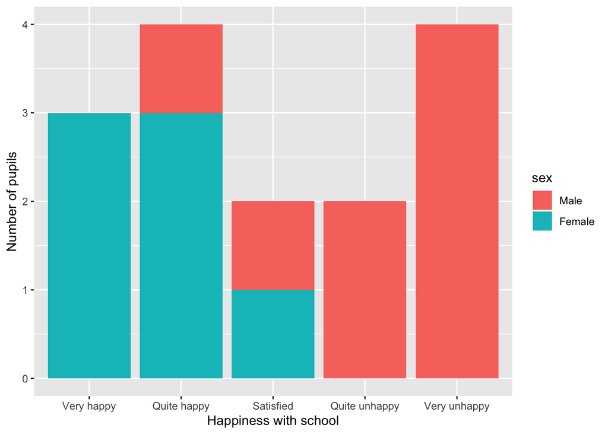

```r
# we tell r to vary the fill colour of the bars by sex

happyggBar <- ggplot(pupils, aes(happy_f, fill=sex))
happyggBar + geom_bar() + labs(x="Happiness with school", y="Number of pupils")
```

**Question 2.** Make a barchart that uses teachers_f, How popular are you with your teachers? div by sex

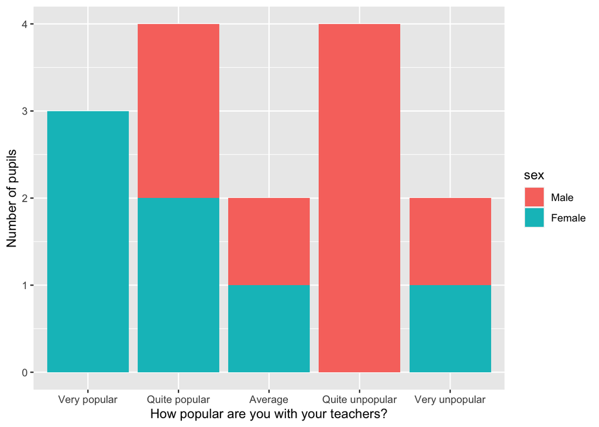

```r
happyggBar <- ggplot(pupils, aes(teachers_f, fill=sex))
happyggBar + geom_bar() + labs(x="How popular are you with your teachers?", y="Number of pupils")
```

# 7 Displaying Histograms for continuous variables

When we plot the distribution of continuous variables such as IQ, it might not be possible or sensible to plot counts for every value (like we did above for sex / happiness). This is because there may be a lot of different IQ values, resulting in a lot of bars, and in small datasets, there might be no cases for some IQ values. We will use *histogram* functions in R, which can combine adjacent values into “bins”.

The FN for building a histogram in base R is hist(). By default, it determines the number of bins by implicitly basing bin sizes on the range of data, but the user can define their own breakpoints between histogram bins. To build a histogram for the IQ values in our dataset:

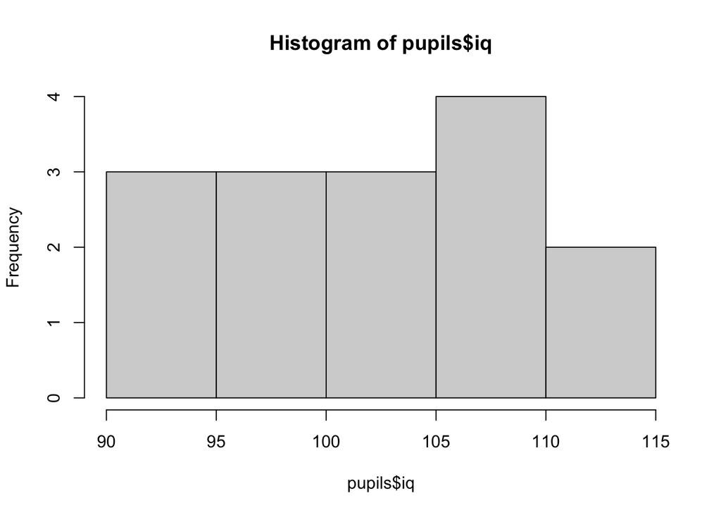

```r
hist(pupils$iq)
```

To produce a histogram in ggplot2:

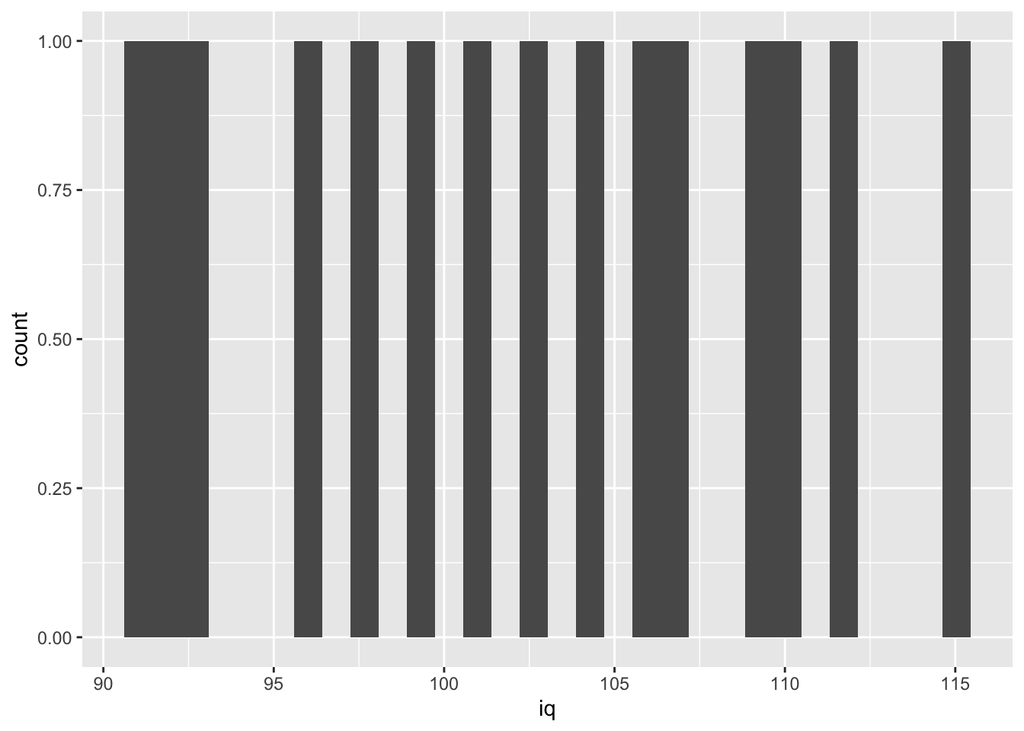

```r
ggplot(pupils, aes(iq)) + geom_histogram()
```

This however, does not look as good, as the data is split into too many bins. We also receive a warning that the number of bins is set to 30 by default, this is too many for the iQ data. We can supply our own value for the bin width (number of iQ points in each bin) to get a histogram similar to the one we produced using the hist() FN.

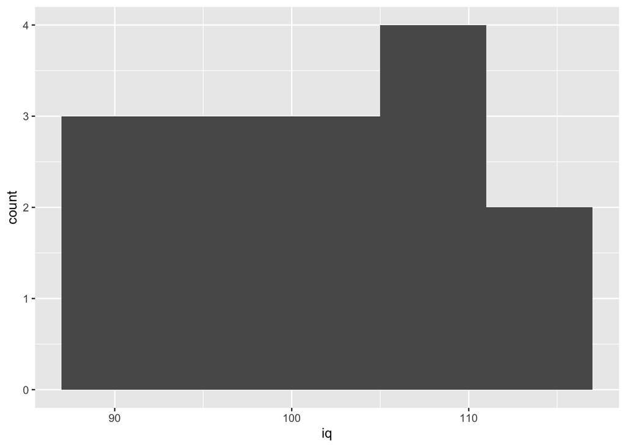

```r
ggplot(pupils, aes(iq)) + geom_histogram(binwidth=6)
```

# 8 Displaying Boxplots

It is useful to summarise the distribution for continuous variables such as iQ without plotting the whole distribution. The distribution can be summarised through a **boxplot** which looks like a box with whiskers. In the center of the box is the **median** value, and the top and bottom of the box corresponds to values between which 50% of the observation fall. The “whiskers” stretch above and below the box to 1.5 times the range in the box (*interquartile range*). Any observations falling outside the range of the whiskers are presented as individual points, some of which may present extreme or unusual values (*outliers*).

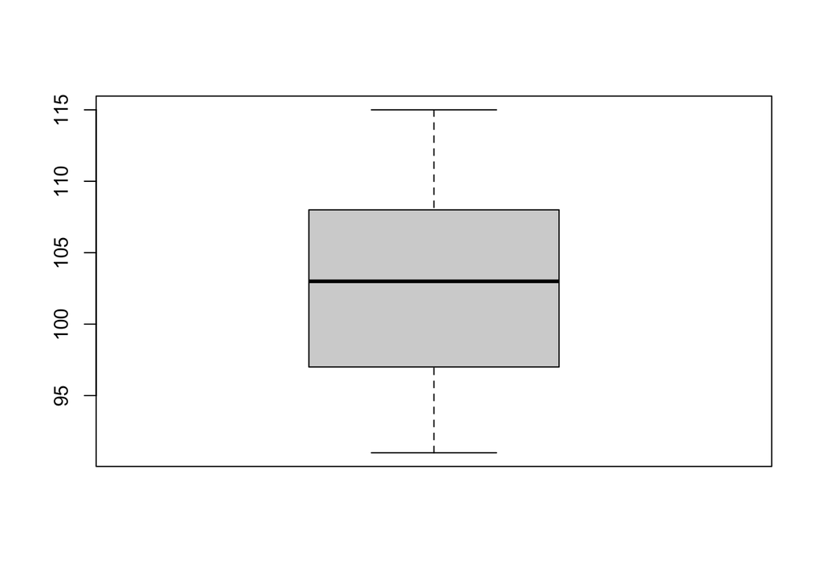

```
boxplot(iq - sex, pupils)
```

```r
boxplot(pupils$iq)
```

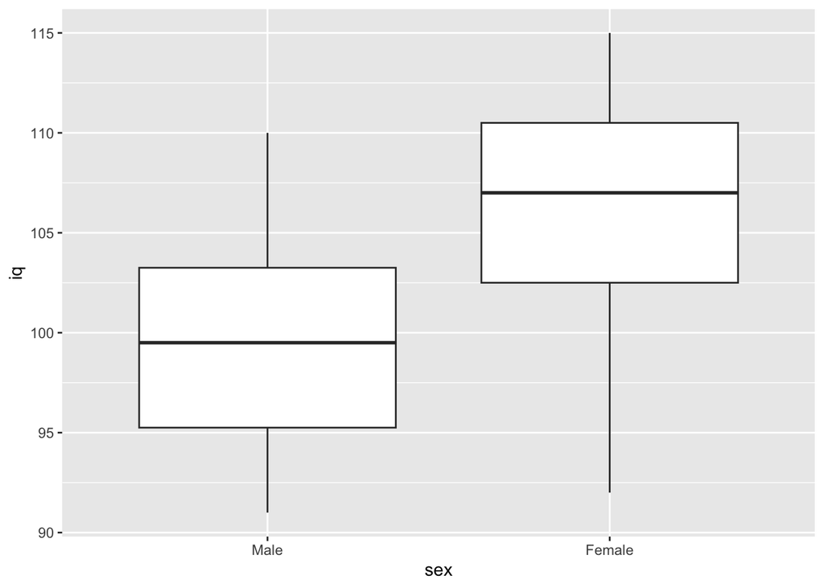

```r
happyggBox <- ggplot(pupils, aes(sex, iq))
happyggBox + geom_boxplot()
```

# 9 Exercise 3: Manipulating Data

We might want to select only a few specific variables or cases from the df, to share this reduced data with a colleague, or to do further analysis only with this subset. We use the general format ’dataframe[rows,columns] to refer to rows (cases) and the columns (variables) that we want.

For example, we may want to create a new df containing only the self-rated happiness, popularity with teachers and friends. For that, we retain all rows (so we do not specify anything before the comma, but list the variable names that we want to select in columns).

```r
pupils_rated <- pupils[ ,c("happy", "teachers", "friends")]
head(pupils_rated)
```

```
##   happy teachers friends
## 1     5        4       3
## 2     5        3       5
## 3     2        2       1
## 4     4        4       4
## 5     1        1       2
## 6     1        5       3
```

For example, we may want to create a new df containing only data for females. To do this, we select rows with sex equal to “Female” (sex==“Female”), and retain all columns (so we do not specify anything after the comma).

```r
pupils_Female <- pupils[pupils$sex=="Female", ]
pupils_Female
```

```
##    pno    sex  iq happy teachers friends     happy_f     teachers_f
## 3    3 Female 107     2        2       1 Quite happy  Quite popular
## 5    5 Female 112     1        1       2  Very happy   Very popular
## 6    6 Female 109     1        5       3  Very happy Very unpopular
## 8    8 Female  92     2        1       5 Quite happy   Very popular
## 9    9 Female 115     1        3       4  Very happy        Average
## 12  12 Female 106     2        1       2 Quite happy   Very popular
## 15  15 Female  99     3        2       1   Satisfied  Quite popular
##          friends_f
## 3     Very popular
## 5    Quite popular
## 6          Average
## 8   Very unpopular
## 9  Quite unpopular
## 12   Quite popular
## 15    Very popular
```

**Question 3.** Now try to create a new dataset selecting only pupils with iQ greater than 100, and retaining only their iQ, sex, and happiness with school.

```r
pupils_new <- pupils[pupils$iq>100 ,c("iq","sex","happy")]
pupils_new
```

```
##     iq    sex happy
## 2  110   Male     5
## 3  107 Female     2
## 5  112 Female     1
## 6  109 Female     1
## 7  101   Male     4
## 9  115 Female     1
## 10 103   Male     3
## 12 106 Female     2
## 14 104   Male     2
```